# Reporting statistical methodology and results

Regression analysis using a general linear model

Author

Affiliation

Jon Yearsley

School of Biology and Environmental Science, UCD

Published

January, 2025

Below is an example of how to report the main analysis from tutorial 11 (Correlation and linear regression in a general linear model”).

**Note**

**Additional advice**

There is some good advice on reporting quantitative information in [Gerstner *et al.* (2017) “Will your paper be used in a meta-analysis? Make the reach of your research broader and longer lasting” (http://doi.org/10.1111/2041-210X.12758)](http://doi.org/10.1111/2041-210X.12758). Figure 1 is especially clear.

# Example Write-Up

## Methods

**The methods section** (describing the **statistical methodology**) needn’t be long and does not explain the details of the R script for the analysis.

The methodology describes the final validated analysis and does not document all the steps (and probably several dead ends) that led up to this final analysis

This study used measurements of testosterone and progesterone concentration (units of pg/mg) from the hair of female wolves captured from population 2 (*n*=48). A general linear model, with progesterone concentration as the response variable and testosterone concentration as the explanatory variable, was fitted to the data by maximum likelihood using the R statistical software (R Core Team, 2024). The model for the i<sup>th</sup> observation can be expressed as
$$P_i = a + b \, T_i + \epsilon_i$$
where $a$ is the fitted intercept and $b$ the fitted slope of the linear relationship between progesterone ($P_i$) and testosterone ($T_i$) concentrations and $\epsilon_i$ is a normally distributed residual with zero mean and standard deviation $\sigma$. Residuals of this fitted model ( $\epsilon_i$ ) were consistent with model assumptions of normality and homogeneity of variance. The model was used to test the null hypothesis that: there is no relationship between testosterone and progesterone concentrations in female wolves from population 2. Hypothesis tests used a critical significance level of 5%.

## Results

**The results section** gives a plain English verbal description of the results followed by the quantitative evidence. The verbal description is intentionally non-technical and avoids words such as ‘statistically significant’. The verbal description is focused upon the stated research question.

The required quantitative evidence is:

**The figure** has a caption which describes the figure without needing to read the methods or the results. The axes of the figure are labelled and the units are specified.

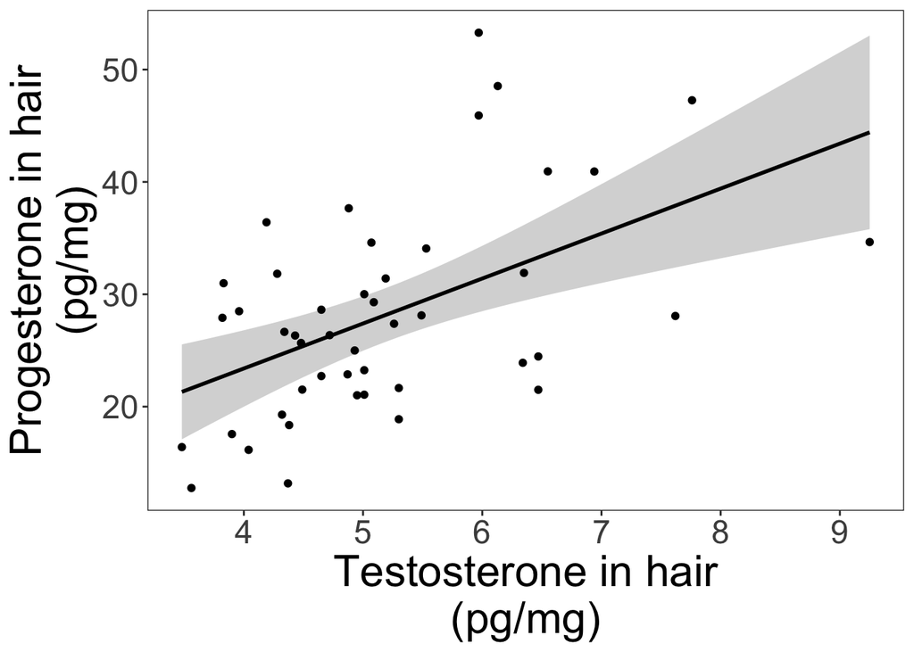

Figure 1: The best-fit linear relationship (solid line) and 95% confidence region (grey shading) between testosterone and progesterone concentrations from 48 hair samples of females wolves in population 2 (data shown as solid points).

## References

R Core Team. (2024). *R: A language and environment for statistical computing*. Vienna, Austria: R Foundation for Statistical Computing. Retrieved from https://www.R-project.org/